# loan_defaulter_prediction_pre-processing

### OCCUPATION_TYPE

```python
dff[dff['ORGANIZATION_TYPE']=='XNA']['NAME_INCOME_TYPE'].value_counts()
```

```
NAME_INCOME_TYPE
Pensioner     55352
Unemployed       22
Name: count, dtype: int64
```

```python
dff[dff['ORGANIZATION_TYPE']=='XNA']['OCCUPATION_TYPE'].isnull().sum()
# for pensioners and unemployed , occupation type is null because they dont have a job. Hence we can impute these values as XNA
```

```
55372
```

```python
p =[]
for i in range(0,len(dff)):
    if dff['ORGANIZATION_TYPE'][i] == 'XNA' and dff['OCCUPATION_TYPE'][i]!=dff['OCCUPATION_TYPE'][i]:
        p.append('retired')
    else:
        p.append(dff['OCCUPATION_TYPE'][i])
p = pd.Series(p)
p.value_counts()
# give it as retired
# different levels can be combinedas one class
```

```
retired                  55372
Laborers                 55186
Sales staff              32102
Core staff               27570
Managers                 21371
Drivers                  18603
High skill tech staff    11380
Accountants               9813
Medicine staff            8537
Security staff            6721
Cooking staff             5946
Cleaning staff            4653
Private service staff     2652
Low-skill Laborers        2093
Waiters/barmen staff      1348
Secretaries               1305
Realty agents              751
HR staff                   563
IT staff                   526
Name: count, dtype: int64
```

```python
len(p)
```

```
307511
```

```python
p.isnull().sum()*100/len(p)
```

```
13.3390350263893
```

```python
dff['OCCUPATION_TYPE'].isnull().sum()
```

```
96391
```

```python
dff['OCCUPATION_TYPE']=p
```

```python
dff['OCCUPATION_TYPE'].isnull().sum()
```

```
41019
```

```python
p =[]
for i in range(0,len(dff)):
    if dff['OCCUPATION_TYPE'][i] == 'Pensioner' and dff['OCCUPATION_TYPE'][i] == 'Unemployed'  :
        p.append('Retired')

    elif dff['OCCUPATION_TYPE'][i] == 'Medicine staff' or dff['OCCUPATION_TYPE'][i] == 'Security staff' or dff['OCCUPATION_TYPE'][i] == 'Cooking staff' or dff['OCCUPATION_TYPE'][i] == 'Cleaning staff' or dff['OCCUPATION_TYPE'][i] == 'Private service staff' or dff['OCCUPATION_TYPE'][i] == 'Waiters/barmen staff' or dff['OCCUPATION_TYPE'][i] == 'Drivers':
        p.append('Services staff')

    elif dff['OCCUPATION_TYPE'][i] == 'Low-skill Laborers' or dff['OCCUPATION_TYPE'][i] == 'Laborers' :
        p.append('Laborers')

    elif dff['OCCUPATION_TYPE'][i] == 'High skill tech staff' or dff['OCCUPATION_TYPE'][i] == 'IT staff' :
        p.append('Technical staff')

    elif dff['OCCUPATION_TYPE'][i] == 'HR staff' or dff['OCCUPATION_TYPE'][i] == 'Accountants' or dff['OCCUPATION_TYPE'][i] == 'Sales staff' or dff['OCCUPATION_TYPE'][i] == 'Realty agents' :
        p.append('HR Finance & Marketing')

    else:
        p.append(dff['OCCUPATION_TYPE'][i])
p = pd.Series(p)
p.value_counts()
```

```
Laborers                  57279
retired                   55372
Services staff            48460
HR Finance & Marketing    43229
Core staff                27570
Managers                  21371
Technical staff           11906
Secretaries                1305
Name: count, dtype: int64
```

```python
dff['OCCUPATION_TYPE']=p
```

```python
ns = dff.isnull().sum()*100/len(dff)
```

```python
ns[ns!=0]
```

```
AMT_ANNUITY                    0.003902
AMT_GOODS_PRICE                0.090403
NAME_TYPE_SUITE                0.420148
OWN_CAR_AGE                    0.001626
OCCUPATION_TYPE               13.339035
CNT_FAM_MEMBERS                0.000650
EXT_SOURCE_1                  56.381073
EXT_SOURCE_2                   0.214626
EXT_SOURCE_3                  19.825307
OBS_30_CNT_SOCIAL_CIRCLE       0.332021
DEF_30_CNT_SOCIAL_CIRCLE       0.332021
OBS_60_CNT_SOCIAL_CIRCLE       0.332021
DEF_60_CNT_SOCIAL_CIRCLE       0.332021
DAYS_LAST_PHONE_CHANGE         0.000325
AMT_REQ_CREDIT_BUREAU_HOUR    13.501631
AMT_REQ_CREDIT_BUREAU_DAY     13.501631
AMT_REQ_CREDIT_BUREAU_WEEK    13.501631
AMT_REQ_CREDIT_BUREAU_MON     13.501631
AMT_REQ_CREDIT_BUREAU_QRT     13.501631
AMT_REQ_CREDIT_BUREAU_YEAR    13.501631
dtype: float64
```

```python
dff['OCCUPATION_TYPE'].value_counts()
```

```
OCCUPATION_TYPE
Laborers                  57279
retired                   55372
Services staff            48460
HR Finance & Marketing    43229
Core staff                27570
Managers                  21371
Technical staff           11906
Secretaries                1305
Name: count, dtype: int64
```

```python
default = dff[dff['TARGET']==1]
```

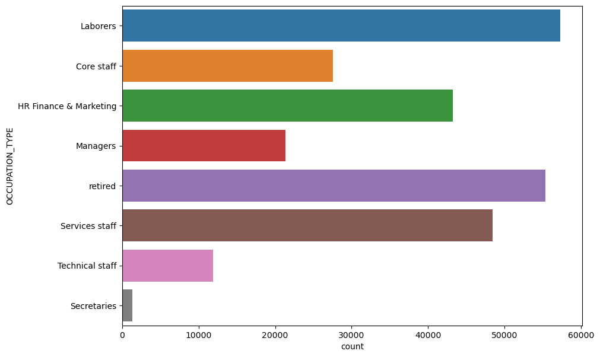

```python
plt.figure(figsize =(10,7))
sns.countplot(y = dff['OCCUPATION_TYPE'])
plt.show()
```

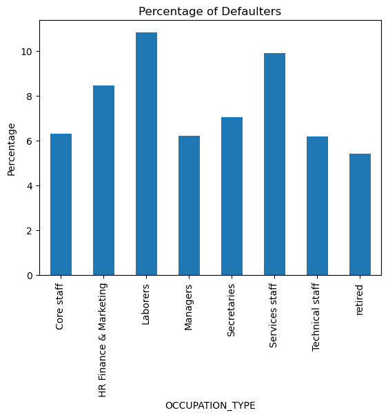

```python
#plt.figure(figsize =(10,7))
(default['OCCUPATION_TYPE'].value_counts()*100/dff['OCCUPATION_TYPE'].value_counts()).plot(kind='bar')
plt.title('Percentage of Defaulters')
plt.ylabel('Percentage')
plt.show()
```

```python
occ = pd.crosstab(dff['TARGET'] , dff['OCCUPATION_TYPE'])
```

HYPOTHESIS

Ho : No relation between OCCUPATION_TYPE and TARGET columns Ha : Relationship exist between OCCUPATION_TYPE and TARGET columns

```python
stats.chi2_contingency(occ)
```

```
Chi2ContingencyResult(statistic=1615.3842726076107, pvalue=0.0, dof=7, expected_freq=array([[25341.88399652, 39735.37552722, 52649.90110397, 19643.86662639,
         1199.53422617, 44543.62344836, 10943.79654924, 50897.01852213],
       [ 2228.11600348,  3493.62447278,  4629.09889603,  1727.13337361,
          105.46577383,  3916.37655164,   962.20345076,  4474.98147787]]))
```

#### p-value is 0. Hence reject the null hypothesis.

#### Thus there is a significant relationship between OCCUPATION_TYPE and TARGET columns

### ORGANIZATION_TYPE

```python
dff['ORGANIZATION_TYPE'].isnull().sum()
```

```
0
```

```python
vc = df['ORGANIZATION_TYPE'].value_counts()
vc
```

```
ORGANIZATION_TYPE
Business Entity Type 3    67992
XNA                       55374
Self-employed             38412
Other                     16683
Medicine                  11193
Business Entity Type 2    10553
Government                10404
School                     8893
Trade: type 7              7831
Kindergarten               6880
Construction               6721
Business Entity Type 1     5984
Transport: type 4          5398
Trade: type 3              3492
Industry: type 9           3368
Industry: type 3           3278
Security                   3247
Housing                    2958
Industry: type 11          2704
Military                   2634
Bank                       2507
Agriculture                2454
Police                     2341
Transport: type 2          2204
Postal                     2157
Security Ministries        1974
Trade: type 2              1900
Restaurant                 1811
Services                   1575
University                 1327
Industry: type 7           1307
Transport: type 3          1187
Industry: type 1           1039
Hotel                       966
Electricity                 950
Industry: type 4            877
Trade: type 6               631
Industry: type 5            599
Insurance                   597
Telecom                     577
Emergency                   560
Industry: type 2            458
Advertising                 429
Realtor                     396
Culture                     379
Industry: type 12           369
Trade: type 1               348
Mobile                      317
Legal Services              305
Cleaning                    260
Transport: type 1           201
Industry: type 6            112
Industry: type 10           109
Religion                     85
Industry: type 13            67
Trade: type 4                64
Trade: type 5                49
Industry: type 8             24
Name: count, dtype: int64
```

```python
len(vc)
```

```
58
```

```python
p =[]
for i in range(0,len(dff)):
    if dff['ORGANIZATION_TYPE'][i] == 'Business Entity Type 3' or dff['ORGANIZATION_TYPE'][i] == 'Business Entity Type 2' or dff['ORGANIZATION_TYPE'][i] == 'Business Entity Type 1' or dff['ORGANIZATION_TYPE'][i] == 'Self-employed' :
        p.append('Business/Self-employed')
    elif dff['ORGANIZATION_TYPE'][i] == 'Trade: type 1' or dff['ORGANIZATION_TYPE'][i] == 'Trade: type 2' or dff['ORGANIZATION_TYPE'][i] == 'Trade: type 3' or dff['ORGANIZATION_TYPE'][i] == 'Trade: type 4' or dff['ORGANIZATION_TYPE'][i] == 'Trade: type 5' or dff['ORGANIZATION_TYPE'][i] == 'Trade: type 6' or dff['ORGANIZATION_TYPE'][i] == 'Trade: type 7' :
        p.append('Trade')
    elif dff['ORGANIZATION_TYPE'][i] == 'Industry: type 1' or dff['ORGANIZATION_TYPE'][i] == 'Industry: type 2' or dff['ORGANIZATION_TYPE'][i] == 'Industry: type 3' or dff['ORGANIZATION_TYPE'][i] == 'Industry: type 4' or dff['ORGANIZATION_TYPE'][i] == 'Industry: type 5' or dff['ORGANIZATION_TYPE'][i] == 'Industry: type 6' or dff['ORGANIZATION_TYPE'][i] == 'Industry: type 7' or dff['ORGANIZATION_TYPE'][i] == 'Industry: type 8' or dff['ORGANIZATION_TYPE'][i] == 'Industry: type 9' or dff['ORGANIZATION_TYPE'][i] == 'Industry: type 10' or dff['ORGANIZATION_TYPE'][i] == 'Industry: type 11' or dff['ORGANIZATION_TYPE'][i] == 'Industry: type 12' or dff['ORGANIZATION_TYPE'][i] == 'Industry: type 13':
        p.append('Industry')
    elif dff['ORGANIZATION_TYPE'][i] == 'Transport: type 1' or dff['ORGANIZATION_TYPE'][i] == 'Transport: type 2' or dff['ORGANIZATION_TYPE'][i] == 'Transport: type 3' or dff['ORGANIZATION_TYPE'][i] == 'Transport: type 4':
        p.append('Transport')
    elif dff['ORGANIZATION_TYPE'][i] == 'XNA' :
        p.append('Retired')
    elif dff['ORGANIZATION_TYPE'][i] == 'Military' or dff['ORGANIZATION_TYPE'][i] == 'Police' :
        p.append('Military/Police')
    elif dff['ORGANIZATION_TYPE'][i] == 'Housing' or dff['ORGANIZATION_TYPE'][i] == 'Construction' :
        p.append('Housing/Construction')
    elif dff['ORGANIZATION_TYPE'][i] == 'Emergency' or dff['ORGANIZATION_TYPE'][i] == 'Insurance' or dff['ORGANIZATION_TYPE'][i] == 'Advertising' or dff['ORGANIZATION_TYPE'][i] == 'Realtor' or dff['ORGANIZATION_TYPE'][i] == 'Culture' or dff['ORGANIZATION_TYPE'][i] == 'Religion'  :
        p.append('Other')
    elif dff['ORGANIZATION_TYPE'][i] == 'Transport' or dff['ORGANIZATION_TYPE'][i] == 'Bank' or dff['ORGANIZATION_TYPE'][i] == 'Cleaning' or dff['ORGANIZATION_TYPE'][i] == 'Security' or dff['ORGANIZATION_TYPE'][i] == 'Postal' or dff['ORGANIZATION_TYPE'][i] == 'Restaurant' or dff['ORGANIZATION_TYPE'][i] == 'Hotel' or dff['ORGANIZATION_TYPE'][i] == 'Telecom' or dff['ORGANIZATION_TYPE'][i] == 'Mobile' or dff['ORGANIZATION_TYPE'][i] == 'Legal Services' :
        p.append('Services')
    elif dff['ORGANIZATION_TYPE'][i] == 'School' or dff['ORGANIZATION_TYPE'][i] == 'University' or dff['ORGANIZATION_TYPE'][i] == 'Kindergarten' :
        p.append('Education')
    else:
        p.append(dff['ORGANIZATION_TYPE'][i])
p = pd.Series(p)
p.value_counts()
```

```
Business/Self-employed    122941
Retired                    55374
Other                      19129
Education                  17100
Trade                      14315
Industry                   14311
Services                   13722
Medicine                   11193
Government                 10404
Housing/Construction        9679
Transport                   8990
Military/Police             4975
Agriculture                 2454
Security Ministries         1974
Electricity                  950
Name: count, dtype: int64
```

```python
dff['ORGANIZATION_TYPE']=p
```

```python
default = dff[dff['TARGET']==1]
```

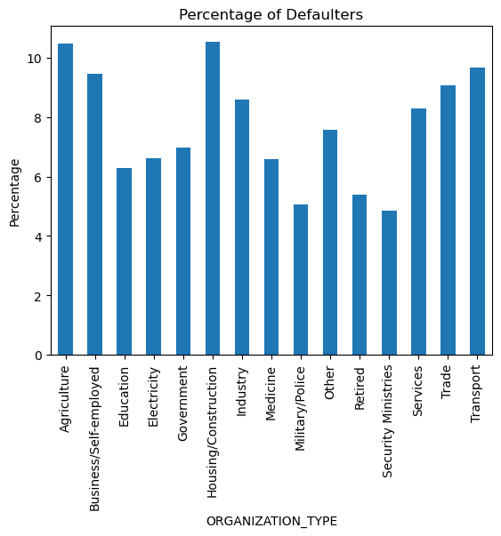

```python
#plt.figure(figsize =(10,5))
(default['ORGANIZATION_TYPE'].value_counts()*100/dff['ORGANIZATION_TYPE'].value_counts()).plot(kind='bar')
plt.title('Percentage of Defaulters')
plt.ylabel('Percentage')
plt.show()
```

```python
# XNA implies no organization
```

```python
org_type = pd.crosstab(dff['ORGANIZATION_TYPE'] , dff['TARGET'])
```

HYPOTHESIS

Ho : No relation between ORGANIZATION_TYPE and TARGET columns Ha : Relationship exist between ORGANIZATION_TYPE and TARGET columns

```python
stats.chi2_contingency(org_type)
```

```
Chi2ContingencyResult(statistic=1222.7003228959138, pvalue=2.2839276639687683e-252, dof=14, expected_freq=array([[2.25589148e+03, 1.98108523e+02],
       [1.13016118e+05, 9.92488179e+03],
       [1.57195372e+04, 1.38046281e+03],
       [8.73307622e+02, 7.66923785e+01],
       [9.56409736e+03, 8.39902638e+02],
       [8.89762576e+03, 7.81374244e+02],
       [1.31556899e+04, 1.15531014e+03],
       [1.02894023e+04, 9.03597676e+02],
       [4.57337412e+03, 4.01625877e+02],
       [1.75847384e+04, 1.54426159e+03],
       [5.09037224e+04, 4.47027765e+03],
       [1.81464131e+03, 1.59358690e+02],
       [1.26142391e+04, 1.10776086e+03],
       [1.31593669e+04, 1.15563305e+03],
       [8.26424791e+03, 7.25752087e+02]]))
```

#### p-value is very less (of the order of -252) and hence < 0.05. Hence reject the null hypothesis.

#### Thus there is a significant relationship between ORGANIZATION_TYPE and TARGET columns

### AMT_REQ_CREDIT_BUREAU_HOUR

```python
dff['AMT_REQ_CREDIT_BUREAU_HOUR'].value_counts()
```

```
AMT_REQ_CREDIT_BUREAU_HOUR
0.0    264366
1.0      1560
2.0        56
3.0         9
4.0         1
Name: count, dtype: int64
```

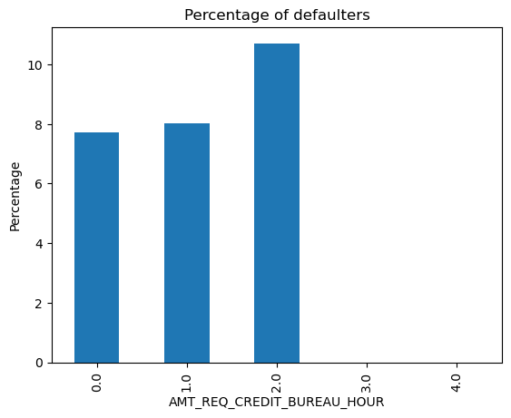

```python
(default['AMT_REQ_CREDIT_BUREAU_HOUR'].value_counts()*100/dff['AMT_REQ_CREDIT_BUREAU_HOUR'].value_counts()).plot(kind='bar')
plt.title('Percentage of defaulters')
plt.ylabel('Percentage')
```

```python
table = pd.crosstab(dff['TARGET'] , dff['AMT_REQ_CREDIT_BUREAU_HOUR'])
table
```

| AMT_REQ_CREDIT_BUREAU_HOUR TARGET | 0.0 | 1.0 | 2.0 | 3.0 | 4.0 |
| --- | --- | --- | --- | --- | --- |
| 0 | 243964 | 1435 | 50 | 9 | 1 |
| 1 | 20402 | 125 | 6 | 0 | 0 |

HYPOTHESIS

Ho : No relation between AMT_REQ_CREDIT_BUREAU_HOUR and TARGET columns Ha : Relationship exist between AMT_REQ_CREDIT_BUREAU_HOUR and TARGET columns

```python
stats.chi2_contingency(table)
```

```
Chi2ContingencyResult(statistic=1.731750821641779, pvalue=0.7849422909043116, dof=4, expected_freq=array([[2.43958518e+05, 1.43957728e+03, 5.16771331e+01, 8.30525354e+00,
        9.22805949e-01],
       [2.04074825e+04, 1.20422719e+02, 4.32286685e+00, 6.94746459e-01,
        7.71940509e-02]]))
```

#### p-value 0.78 > 0.05. Hence failed to reject the null hypothesis.

#### Thus there is no significant relationship between AMT_REQ_CREDIT_BUREAU_HOUR and TARGET columns

### AMT_REQ_CREDIT_BUREAU_DAY

```python
dff['AMT_REQ_CREDIT_BUREAU_DAY'].value_counts()
```

```
AMT_REQ_CREDIT_BUREAU_DAY
0.0    264503
1.0      1292
2.0       106
3.0        45
4.0        26
5.0         9
6.0         8
9.0         2
8.0         1
Name: count, dtype: int64
```

```python
default['AMT_REQ_CREDIT_BUREAU_DAY'].value_counts()
```

```
AMT_REQ_CREDIT_BUREAU_DAY
0.0    20392
1.0      125
2.0       11
4.0        3
3.0        2
Name: count, dtype: int64
```

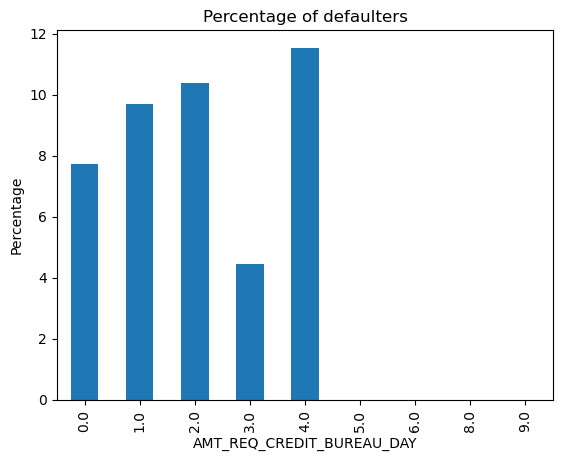

```python
(default['AMT_REQ_CREDIT_BUREAU_DAY'].value_counts()*100/dff['AMT_REQ_CREDIT_BUREAU_DAY'].value_counts()).plot(kind='bar')
plt.title('Percentage of defaulters')
plt.ylabel('Percentage')
```

```python
table = pd.crosstab(dff['TARGET'] , dff['AMT_REQ_CREDIT_BUREAU_DAY'])
table
```

| AMT_REQ_CREDIT_BUREAU_DAY TARGET | 0.0 | 1.0 | 2.0 | 3.0 | 4.0 | 5.0 | 6.0 | 8.0 | 9.0 |
| --- | --- | --- | --- | --- | --- | --- | --- | --- | --- |
| 0 | 244111 | 1167 | 95 | 43 | 23 | 9 | 8 | 1 | 2 |
| 1 | 20392 | 125 | 11 | 2 | 3 | 0 | 0 | 0 | 0 |

HYPOTHESIS

Ho : No relation between AMT_REQ_CREDIT_BUREAU_DAY and TARGET columns Ha : Relationship exist between AMT_REQ_CREDIT_BUREAU_DAY and TARGET columns

```python
stats.chi2_contingency(table)
```

```
Chi2ContingencyResult(statistic=10.90591591325121, pvalue=0.20708733762785336, dof=8, expected_freq=array([[2.44084942e+05, 1.19226529e+03, 9.78174306e+01, 4.15262677e+01,
        2.39929547e+01, 8.30525354e+00, 7.38244759e+00, 9.22805949e-01,
        1.84561190e+00],
       [2.04180581e+04, 9.97347138e+01, 8.18256940e+00, 3.47373229e+00,
        2.00704532e+00, 6.94746459e-01, 6.17552408e-01, 7.71940509e-02,
        1.54388102e-01]]))
```

#### p-value 0.2 > 0.05. Hence failed to reject the null hypothesis.

#### Thus there is no significant relationship between AMT_REQ_CREDIT_BUREAU_DAY and TARGET columns

### AMT_REQ_CREDIT_BUREAU_WEEK

```python
dff['AMT_REQ_CREDIT_BUREAU_WEEK'].value_counts()
```

```
AMT_REQ_CREDIT_BUREAU_WEEK
0.0    257456
1.0      8208
2.0       199
3.0        58
4.0        34
6.0        20
5.0        10
8.0         5
7.0         2
Name: count, dtype: int64
```

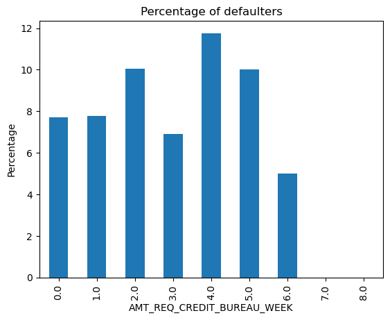

```python
(default['AMT_REQ_CREDIT_BUREAU_WEEK'].value_counts()*100/dff['AMT_REQ_CREDIT_BUREAU_WEEK'].value_counts()).plot(kind='bar')
plt.title('Percentage of defaulters')
plt.ylabel('Percentage')
```

```python
table = pd.crosstab(dff['TARGET'] , dff['AMT_REQ_CREDIT_BUREAU_WEEK'])
table
```

| AMT_REQ_CREDIT_BUREAU_WEEK TARGET | 0.0 | 1.0 | 2.0 | 3.0 | 4.0 | 5.0 | 6.0 | 7.0 | 8.0 |
| --- | --- | --- | --- | --- | --- | --- | --- | --- | --- |
| 0 | 237591 | 7570 | 179 | 54 | 30 | 9 | 19 | 2 | 5 |
| 1 | 19865 | 638 | 20 | 4 | 4 | 1 | 1 | 0 | 0 |

HYPOTHESIS

Ho : No relation between AMT_REQ_CREDIT_BUREAU_WEEK and TARGET columns Ha : Relationship exist between AMT_REQ_CREDIT_BUREAU_WEEK and TARGET columns

```python
stats.chi2_contingency(table)
```

```
Chi2ContingencyResult(statistic=3.257559513915368, pvalue=0.917170137144379, dof=8, expected_freq=array([[2.37581928e+05, 7.57439123e+03, 1.83638384e+02, 5.35227450e+01,
        3.13754023e+01, 9.22805949e+00, 1.84561190e+01, 1.84561190e+00,
        4.61402975e+00],
       [1.98740716e+04, 6.33608770e+02, 1.53616161e+01, 4.47725496e+00,
        2.62459773e+00, 7.71940509e-01, 1.54388102e+00, 1.54388102e-01,
        3.85970255e-01]]))
```

#### p-value 0.9 > 0.05. Hence failed to reject the null hypothesis.

#### Thus there is no significant relationship between AMT_REQ_CREDIT_BUREAU_WEEK and TARGET columns

### AMT_REQ_CREDIT_BUREAU_MON

```python
dff['AMT_REQ_CREDIT_BUREAU_MON'].value_counts()
```

```
AMT_REQ_CREDIT_BUREAU_MON
0.0     222233
1.0      33147
2.0       5386
3.0       1991
4.0       1076
5.0        602
6.0        343
7.0        298
9.0        206
8.0        185
10.0       132
11.0       119
12.0        77
13.0        72
14.0        40
15.0        35
16.0        23
17.0        14
18.0         6
19.0         3
24.0         1
23.0         1
27.0         1
22.0         1
Name: count, dtype: int64
```

```python
default['AMT_REQ_CREDIT_BUREAU_MON'].value_counts()
```

```
AMT_REQ_CREDIT_BUREAU_MON
0.0     17315
1.0      2560
2.0       379
3.0       108
4.0        60
5.0        40
6.0        18
7.0        17
10.0       11
9.0         8
8.0         6
11.0        4
13.0        3
12.0        1
15.0        1
17.0        1
14.0        1
Name: count, dtype: int64
```

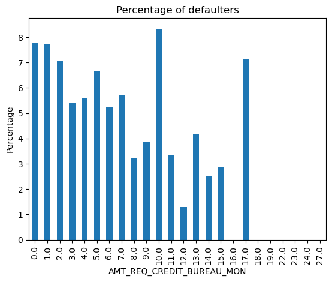

```python
(default['AMT_REQ_CREDIT_BUREAU_MON'].value_counts()*100/dff['AMT_REQ_CREDIT_BUREAU_MON'].value_counts()).plot(kind='bar')
plt.title('Percentage of defaulters')
plt.ylabel('Percentage')
```

```python
table = pd.crosstab(dff['TARGET'] , dff['AMT_REQ_CREDIT_BUREAU_MON'])
table
```

| AMT_REQ_CREDIT_BUREAU_MON TARGET | 0.0 | 1.0 | 2.0 | 3.0 | 4.0 | 5.0 | 6.0 | 7.0 | 8.0 | 9.0 | ... | 14.0 | 15.0 | 16.0 | 17.0 | 18.0 | 19.0 | 22.0 | 23.0 | 24.0 | 27.0 |
| --- | --- | --- | --- | --- | --- | --- | --- | --- | --- | --- | --- | --- | --- | --- | --- | --- | --- | --- | --- | --- | --- |
| 0 | 204918 | 30587 | 5007 | 1883 | 1016 | 562 | 325 | 281 | 179 | 198 | ... | 39 | 34 | 23 | 13 | 6 | 3 | 1 | 1 | 1 | 1 |
| 1 | 17315 | 2560 | 379 | 108 | 60 | 40 | 18 | 17 | 6 | 8 | ... | 1 | 1 | 0 | 1 | 0 | 0 | 0 | 0 | 0 | 0 |

2 rows × 24 columns

HYPOTHESIS

Ho : No relation between AMT_REQ_CREDIT_BUREAU_MON and TARGET columns Ha : Relationship exist between AMT_REQ_CREDIT_BUREAU_MON and TARGET columns

```python
stats.chi2_contingency(table)
```

```
Chi2ContingencyResult(statistic=56.557215014461796, pvalue=0.00011825822466825444, dof=23, expected_freq=array([[2.05077934e+05, 3.05882488e+04, 4.97023284e+03, 1.83730664e+03,
        9.92939201e+02, 5.55529181e+02, 3.16522441e+02, 2.74996173e+02,
        1.70719101e+02, 1.90098026e+02, 1.21810385e+02, 1.09813908e+02,
        7.10560581e+01, 6.64420283e+01, 3.69122380e+01, 3.22982082e+01,
        2.12245368e+01, 1.29192833e+01, 5.53683569e+00, 2.76841785e+00,
        9.22805949e-01, 9.22805949e-01, 9.22805949e-01, 9.22805949e-01],
       [1.71550655e+04, 2.55875121e+03, 4.15767158e+02, 1.53693355e+02,
        8.30607988e+01, 4.64708187e+01, 2.64775595e+01, 2.30038272e+01,
        1.42808994e+01, 1.59019745e+01, 1.01896147e+01, 9.18609206e+00,
        5.94394192e+00, 5.55797167e+00, 3.08776204e+00, 2.70179178e+00,
        1.77546317e+00, 1.08071671e+00, 4.63164306e-01, 2.31582153e-01,
        7.71940509e-02, 7.71940509e-02, 7.71940509e-02, 7.71940509e-02]]))
```

#### p-value 0.0001 < 0.05. Hence reject the null hypothesis.

#### Thus there is a significant relationship between AMT_REQ_CREDIT_BUREAU_MON and TARGET columns

### AMT_REQ_CREDIT_BUREAU_QRT

```python
dff['AMT_REQ_CREDIT_BUREAU_QRT'].value_counts()
```

```
AMT_REQ_CREDIT_BUREAU_QRT
0.0      215417
1.0       33862
2.0       14412
3.0        1717
4.0         476
5.0          64
6.0          28
8.0           7
7.0           7
261.0         1
19.0          1
Name: count, dtype: int64
```

```python
default['AMT_REQ_CREDIT_BUREAU_QRT'].value_counts()
```

```
AMT_REQ_CREDIT_BUREAU_QRT
0.0     16905
1.0      2227
2.0      1203
3.0       126
4.0        57
6.0         7
5.0         6
7.0         1
19.0        1
Name: count, dtype: int64
```

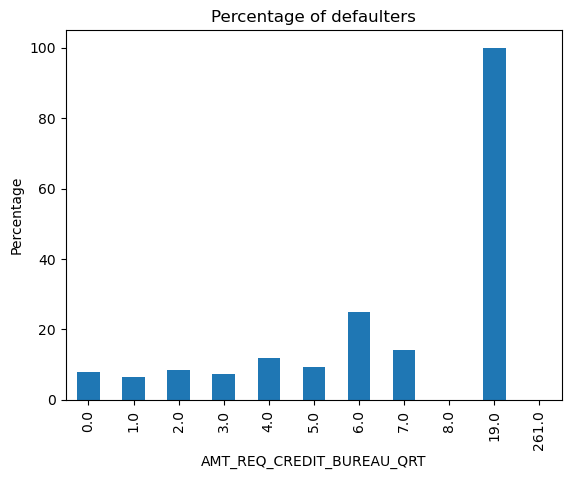

```python
(default['AMT_REQ_CREDIT_BUREAU_QRT'].value_counts()*100/dff['AMT_REQ_CREDIT_BUREAU_QRT'].value_counts()).plot(kind='bar')
plt.title('Percentage of defaulters')
plt.ylabel('Percentage')
```

```python
table = pd.crosstab(dff['TARGET'] , dff['AMT_REQ_CREDIT_BUREAU_QRT'])
table
```

| AMT_REQ_CREDIT_BUREAU_QRT TARGET | 0.0 | 1.0 | 2.0 | 3.0 | 4.0 | 5.0 | 6.0 | 7.0 | 8.0 | 19.0 | 261.0 |
| --- | --- | --- | --- | --- | --- | --- | --- | --- | --- | --- | --- |
| 0 | 198512 | 31635 | 13209 | 1591 | 419 | 58 | 21 | 6 | 7 | 0 | 1 |
| 1 | 16905 | 2227 | 1203 | 126 | 57 | 6 | 7 | 1 | 0 | 1 | 0 |

HYPOTHESIS

Ho : No relation between AMT_REQ_CREDIT_BUREAU_QRT and TARGET columns Ha : Relationship exist between AMT_REQ_CREDIT_BUREAU_QRT and TARGET columns

```python
stats.chi2_contingency(table)
```

```
Chi2ContingencyResult(statistic=112.49407068941916, pvalue=1.67431405509798e-19, dof=10, expected_freq=array([[1.98788089e+05, 3.12480550e+04, 1.32994793e+04, 1.58445781e+03,
        4.39255632e+02, 5.90595807e+01, 2.58385666e+01, 6.45964164e+00,
        6.45964164e+00, 9.22805949e-01, 9.22805949e-01],
       [1.66289109e+04, 2.61394495e+03, 1.11252066e+03, 1.32542185e+02,
        3.67443683e+01, 4.94041926e+00, 2.16143343e+00, 5.40358357e-01,
        5.40358357e-01, 7.71940509e-02, 7.71940509e-02]]))
```

#### p-value is very less (of the order of -19) and hence < 0.05. Hence reject the null hypothesis.

#### Thus there is a significant relationship between AMT_REQ_CREDIT_BUREAU_QRT and TARGET columns

### AMT_REQ_CREDIT_BUREAU_YEAR

```python
dff['AMT_REQ_CREDIT_BUREAU_YEAR'].value_counts()
```

```
AMT_REQ_CREDIT_BUREAU_YEAR
0.0     71801
1.0     63405
2.0     50192
3.0     33628
4.0     20714
5.0     12052
6.0      6967
7.0      3869
8.0      2127
9.0      1096
11.0       31
12.0       30
10.0       22
13.0       19
14.0       10
17.0        7
15.0        6
19.0        4
18.0        4
16.0        3
25.0        1
23.0        1
22.0        1
21.0        1
20.0        1
Name: count, dtype: int64
```

```python
default['AMT_REQ_CREDIT_BUREAU_YEAR'].value_counts()
```

```
AMT_REQ_CREDIT_BUREAU_YEAR
0.0     5123
1.0     4650
2.0     4068
3.0     2676
4.0     1710
5.0     1003
6.0      632
7.0      356
8.0      183
9.0      119
10.0       3
14.0       3
11.0       2
12.0       2
16.0       1
22.0       1
13.0       1
Name: count, dtype: int64
```

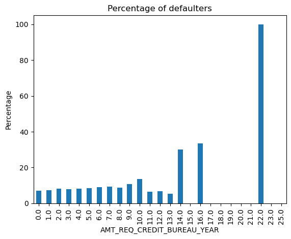

```python
(default['AMT_REQ_CREDIT_BUREAU_YEAR'].value_counts()*100/dff['AMT_REQ_CREDIT_BUREAU_YEAR'].value_counts()).plot(kind='bar')
plt.title('Percentage of defaulters')
plt.ylabel('Percentage')
```

```python
table = pd.crosstab(dff['TARGET'] , dff['AMT_REQ_CREDIT_BUREAU_YEAR'])
table
```

| AMT_REQ_CREDIT_BUREAU_YEAR TARGET | 0.0 | 1.0 | 2.0 | 3.0 | 4.0 | 5.0 | 6.0 | 7.0 | 8.0 | 9.0 | ... | 15.0 | 16.0 | 17.0 | 18.0 | 19.0 | 20.0 | 21.0 | 22.0 | 23.0 | 25.0 |
| --- | --- | --- | --- | --- | --- | --- | --- | --- | --- | --- | --- | --- | --- | --- | --- | --- | --- | --- | --- | --- | --- |
| 0 | 66678 | 58755 | 46124 | 30952 | 19004 | 11049 | 6335 | 3513 | 1944 | 977 | ... | 6 | 2 | 7 | 4 | 4 | 1 | 1 | 0 | 1 | 1 |
| 1 | 5123 | 4650 | 4068 | 2676 | 1710 | 1003 | 632 | 356 | 183 | 119 | ... | 0 | 1 | 0 | 0 | 0 | 0 | 0 | 1 | 0 | 0 |

2 rows × 25 columns

HYPOTHESIS

Ho : No relation between AMT_REQ_CREDIT_BUREAU_YEAR and TARGET columns Ha : Relationship exist between AMT_REQ_CREDIT_BUREAU_YEAR and TARGET columns

```python
stats.chi2_contingency(table)
```

```
Chi2ContingencyResult(statistic=147.7345854930939, pvalue=8.720141441511281e-20, dof=24, expected_freq=array([[6.62583899e+04, 5.85105112e+04, 4.63174762e+04, 3.10321185e+04,
        1.91150024e+04, 1.11216573e+04, 6.42918905e+03, 3.57033622e+03,
        1.96280825e+03, 1.01139532e+03, 2.03017309e+01, 2.86069844e+01,
        2.76841785e+01, 1.75333130e+01, 9.22805949e+00, 5.53683569e+00,
        2.76841785e+00, 6.45964164e+00, 3.69122380e+00, 3.69122380e+00,
        9.22805949e-01, 9.22805949e-01, 9.22805949e-01, 9.22805949e-01,
        9.22805949e-01],
       [5.54261005e+03, 4.89448880e+03, 3.87452381e+03, 2.59588155e+03,
        1.59899757e+03, 9.30342702e+02, 5.37810953e+02, 2.98663783e+02,
        1.64191746e+02, 8.46046798e+01, 1.69826912e+00, 2.39301558e+00,
        2.31582153e+00, 1.46668697e+00, 7.71940509e-01, 4.63164306e-01,
        2.31582153e-01, 5.40358357e-01, 3.08776204e-01, 3.08776204e-01,
        7.71940509e-02, 7.71940509e-02, 7.71940509e-02, 7.71940509e-02,
        7.71940509e-02]]))
```

#### p-value is very less (of the order of -20) and hence < 0.05. Hence reject the null hypothesis.

#### Thus there is a significant relationship between AMT_REQ_CREDIT_BUREAU_YEAR and TARGET columns

### FLAG DOCUMENTS

```python
document = dff.iloc[:,48:68]
```

```python
doc_cols = document.columns
```

```python
document.head()
```

|  | FLAG_DOCUMENT_2 | FLAG_DOCUMENT_3 | FLAG_DOCUMENT_4 | FLAG_DOCUMENT_5 | FLAG_DOCUMENT_6 | FLAG_DOCUMENT_7 | FLAG_DOCUMENT_8 | FLAG_DOCUMENT_9 | FLAG_DOCUMENT_10 | FLAG_DOCUMENT_11 | FLAG_DOCUMENT_12 | FLAG_DOCUMENT_13 | FLAG_DOCUMENT_14 | FLAG_DOCUMENT_15 | FLAG_DOCUMENT_16 | FLAG_DOCUMENT_17 | FLAG_DOCUMENT_18 | FLAG_DOCUMENT_19 | FLAG_DOCUMENT_20 | FLAG_DOCUMENT_21 |
| --- | --- | --- | --- | --- | --- | --- | --- | --- | --- | --- | --- | --- | --- | --- | --- | --- | --- | --- | --- | --- |
| 0 | 0 | 1 | 0 | 0 | 0 | 0 | 0 | 0 | 0 | 0 | 0 | 0 | 0 | 0 | 0 | 0 | 0 | 0 | 0 | 0 |
| 1 | 0 | 1 | 0 | 0 | 0 | 0 | 0 | 0 | 0 | 0 | 0 | 0 | 0 | 0 | 0 | 0 | 0 | 0 | 0 | 0 |
| 2 | 0 | 0 | 0 | 0 | 0 | 0 | 0 | 0 | 0 | 0 | 0 | 0 | 0 | 0 | 0 | 0 | 0 | 0 | 0 | 0 |
| 3 | 0 | 1 | 0 | 0 | 0 | 0 | 0 | 0 | 0 | 0 | 0 | 0 | 0 | 0 | 0 | 0 | 0 | 0 | 0 | 0 |
| 4 | 0 | 0 | 0 | 0 | 0 | 0 | 1 | 0 | 0 | 0 | 0 | 0 | 0 | 0 | 0 | 0 | 0 | 0 | 0 | 0 |

```python
document.info()
```

```
<class 'pandas.core.frame.DataFrame'>
RangeIndex: 307511 entries, 0 to 307510
Data columns (total 20 columns):
 #   Column            Non-Null Count   Dtype
---  ------            --------------   -----
 0   FLAG_DOCUMENT_2   307511 non-null  int64
 1   FLAG_DOCUMENT_3   307511 non-null  int64
 2   FLAG_DOCUMENT_4   307511 non-null  int64
 3   FLAG_DOCUMENT_5   307511 non-null  int64
 4   FLAG_DOCUMENT_6   307511 non-null  int64
 5   FLAG_DOCUMENT_7   307511 non-null  int64
 6   FLAG_DOCUMENT_8   307511 non-null  int64
 7   FLAG_DOCUMENT_9   307511 non-null  int64
 8   FLAG_DOCUMENT_10  307511 non-null  int64
 9   FLAG_DOCUMENT_11  307511 non-null  int64
 10  FLAG_DOCUMENT_12  307511 non-null  int64
 11  FLAG_DOCUMENT_13  307511 non-null  int64
 12  FLAG_DOCUMENT_14  307511 non-null  int64
 13  FLAG_DOCUMENT_15  307511 non-null  int64
 14  FLAG_DOCUMENT_16  307511 non-null  int64
 15  FLAG_DOCUMENT_17  307511 non-null  int64
 16  FLAG_DOCUMENT_18  307511 non-null  int64
 17  FLAG_DOCUMENT_19  307511 non-null  int64
 18  FLAG_DOCUMENT_20  307511 non-null  int64
 19  FLAG_DOCUMENT_21  307511 non-null  int64
dtypes: int64(20)
memory usage: 46.9 MB
```

```python
for i in document.columns:
    document[i] = document[i]/document[i].sum()
```

```python
document.head()
```

|  | FLAG_DOCUMENT_2 | FLAG_DOCUMENT_3 | FLAG_DOCUMENT_4 | FLAG_DOCUMENT_5 | FLAG_DOCUMENT_6 | FLAG_DOCUMENT_7 | FLAG_DOCUMENT_8 | FLAG_DOCUMENT_9 | FLAG_DOCUMENT_10 | FLAG_DOCUMENT_11 | FLAG_DOCUMENT_12 | FLAG_DOCUMENT_13 | FLAG_DOCUMENT_14 | FLAG_DOCUMENT_15 | FLAG_DOCUMENT_16 | FLAG_DOCUMENT_17 | FLAG_DOCUMENT_18 | FLAG_DOCUMENT_19 | FLAG_DOCUMENT_20 | FLAG_DOCUMENT_21 |
| --- | --- | --- | --- | --- | --- | --- | --- | --- | --- | --- | --- | --- | --- | --- | --- | --- | --- | --- | --- | --- |
| 0 | 0.0 | 0.000005 | 0.0 | 0.0 | 0.0 | 0.0 | 0.00000 | 0.0 | 0.0 | 0.0 | 0.0 | 0.0 | 0.0 | 0.0 | 0.0 | 0.0 | 0.0 | 0.0 | 0.0 | 0.0 |
| 1 | 0.0 | 0.000005 | 0.0 | 0.0 | 0.0 | 0.0 | 0.00000 | 0.0 | 0.0 | 0.0 | 0.0 | 0.0 | 0.0 | 0.0 | 0.0 | 0.0 | 0.0 | 0.0 | 0.0 | 0.0 |
| 2 | 0.0 | 0.000000 | 0.0 | 0.0 | 0.0 | 0.0 | 0.00000 | 0.0 | 0.0 | 0.0 | 0.0 | 0.0 | 0.0 | 0.0 | 0.0 | 0.0 | 0.0 | 0.0 | 0.0 | 0.0 |
| 3 | 0.0 | 0.000005 | 0.0 | 0.0 | 0.0 | 0.0 | 0.00000 | 0.0 | 0.0 | 0.0 | 0.0 | 0.0 | 0.0 | 0.0 | 0.0 | 0.0 | 0.0 | 0.0 | 0.0 | 0.0 |
| 4 | 0.0 | 0.000000 | 0.0 | 0.0 | 0.0 | 0.0 | 0.00004 | 0.0 | 0.0 | 0.0 | 0.0 | 0.0 | 0.0 | 0.0 | 0.0 | 0.0 | 0.0 | 0.0 | 0.0 | 0.0 |

```python
dff['FLAG_DOC_SCORE'] =document.sum(axis = 1)
```

```python
for i in document.columns:
    print(document[i].value_counts())

# giving weightage to columns based on the sum of dcuments submitted
```

```
FLAG_DOCUMENT_2
0.000000    307498
0.076923        13
Name: count, dtype: int64
FLAG_DOCUMENT_3
0.000005    218340
0.000000     89171
Name: count, dtype: int64
FLAG_DOCUMENT_4
0.00    307486
0.04        25
Name: count, dtype: int64
FLAG_DOCUMENT_5
0.000000    302863
0.000215      4648
Name: count, dtype: int64
FLAG_DOCUMENT_6
0.000000    280433
0.000037     27078
Name: count, dtype: int64
FLAG_DOCUMENT_7
0.000000    307452
0.016949        59
Name: count, dtype: int64
FLAG_DOCUMENT_8
0.00000    282487
0.00004     25024
Name: count, dtype: int64
FLAG_DOCUMENT_9
0.000000    306313
0.000835      1198
Name: count, dtype: int64
FLAG_DOCUMENT_10
0.000000    307504
0.142857         7
Name: count, dtype: int64
FLAG_DOCUMENT_11
0.000000    306308
0.000831      1203
Name: count, dtype: int64
```

[output cut: 25 more lines]

```
0.0000    305011
0.0004      2500
Name: count, dtype: int64
FLAG_DOCUMENT_19
0.000000    307328
0.005464       183
Name: count, dtype: int64
FLAG_DOCUMENT_20
0.00000    307355
0.00641       156
Name: count, dtype: int64
FLAG_DOCUMENT_21
0.000000    307408
0.009709       103
Name: count, dtype: int64
```

```python
dff[doc_cols] = document
```

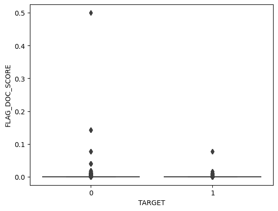

```python
sns.boxplot(x = dff['TARGET'] ,y = dff['FLAG_DOC_SCORE'])
```

```python
dff['FLAG_DOC_SCORE'].describe()
```

```
count    307511.000000
mean          0.000065
std           0.001632
min           0.000000
25%           0.000005
50%           0.000005
75%           0.000005
max           0.500040
Name: FLAG_DOC_SCORE, dtype: float64
```

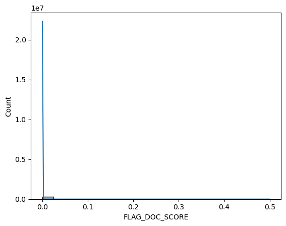

```python
sns.histplot(data=dff, x='FLAG_DOC_SCORE', kde=True)
plt.show()
```

```python
default = dff[dff['TARGET']==1]
non_default = dff[dff['TARGET']==0]
```

```python
default_score = default['FLAG_DOC_SCORE']
non_default_score = non_default['FLAG_DOC_SCORE']
```

HYPOTHESIS

Ho : No relation between FLAG_DOC_SCORE and TARGET columns Ha : Relationship exist between FLAG_DOC_SCORE and TARGET columns

```python
stats.shapiro(default_score)
```

```
ShapiroResult(statistic=0.01725939909248908, pvalue=6.892891321050713e-142)
```

```python
stats.mannwhitneyu(default_score , non_default_score)
```

```
MannwhitneyuResult(statistic=3447012874.5, pvalue=1.782400933168907e-08)
```

```python
stats.kruskal(default_score , non_default_score)
```

```
KruskalResult(statistic=31.718242903094676, pvalue=1.7824004623197254e-08)
```

#### p-value is very less (of the order of -08) and hence < 0.05. Hence reject the null hypothesis.

#### Thus there is a significant relationship between FLAG_DOC_SCORE and TARGET columns

### EXT SOURCE

```python
ext = dff.iloc[:,40:43]
```

```python
ext
```

|  | EXT_SOURCE_1 | EXT_SOURCE_2 | EXT_SOURCE_3 |
| --- | --- | --- | --- |
| 0 | 0.083037 | 0.262949 | 0.139376 |
| 1 | 0.311267 | 0.622246 | NaN |
| 2 | NaN | 0.555912 | 0.729567 |
| 3 | NaN | 0.650442 | NaN |
| 4 | NaN | 0.322738 | NaN |
| ... | ... | ... | ... |
| 307506 | 0.145570 | 0.681632 | NaN |
| 307507 | NaN | 0.115992 | NaN |
| 307508 | 0.744026 | 0.535722 | 0.218859 |
| 307509 | NaN | 0.514163 | 0.661024 |
| 307510 | 0.734460 | 0.708569 | 0.113922 |

307511 rows × 3 columns

```python
# Replace NaN values with 0 to handle calculations
ext = ext.fillna(0)

# Calculate the average based on non-NaN values
ext_avg = (ext.iloc[:, 0] + ext.iloc[:, 1] + ext.iloc[:, 2]) / 3

# Add the calculated average to the 'dff' DataFrame
dff['EXT_SOURCE_AVG'] = ext_avg
```

```python
dff['EXT_SOURCE_AVG']
```

```
0         0.161787
1         0.311171
2         0.428493
3         0.216814
4         0.107579
            ...
307506    0.275734
307507    0.038664
307508    0.499536
307509    0.391729
307510    0.518984
Name: EXT_SOURCE_AVG, Length: 307511, dtype: float64
```

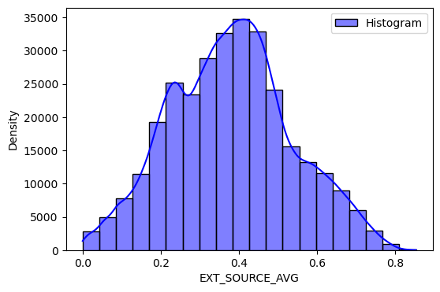

```python
plt.figure(figsize=(6, 4))
sns.histplot(data=dff, x='EXT_SOURCE_AVG', bins=20, kde=True, color='blue', label='Histogram')
plt.xlabel('EXT_SOURCE_AVG')
plt.ylabel('Density')
plt.legend()
plt.show()
```

```python
dff['EXT_SOURCE_AVG'].skew()
```

```
0.1152751226937647
```

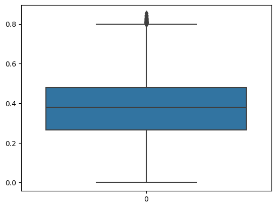

```python
sns.boxplot(dff['EXT_SOURCE_AVG'])
```

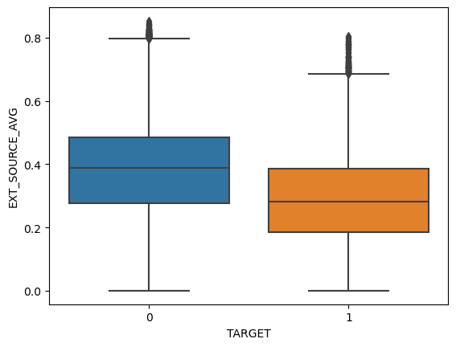

```python
sns.boxplot(y = dff['EXT_SOURCE_AVG'] , x = dff['TARGET'])
```

```python
default = dff[dff['TARGET']==1]
non_default = dff[dff['TARGET']==0]
```

```python
default_score = default['EXT_SOURCE_AVG']
non_default_score = non_default['EXT_SOURCE_AVG']
```

HYPOTHESIS

Ho : No relation between EXT_SOURCE_1,EXT_SOURCE_2, EXT_SOURCE_3 and TARGET columns Ha : Relationship exist between EXT_SOURCE_1,EXT_SOURCE_2, EXT_SOURCE_3 and TARGET columns

```python
stats.shapiro(dff['EXT_SOURCE_AVG'])
```

```
ShapiroResult(statistic=0.9950730781798549, pvalue=2.2504286100143913e-59)
```

```python
stats.mannwhitneyu(default_score , non_default_score)
```

```
MannwhitneyuResult(statistic=2234526624.5, pvalue=0.0)
```